# CARET demo

## Installation

```r
install.packages("caret", dependencies = c("Depends", "Suggests"))
```

## Load required libraries

```r
library(caret)
library(doMC)
```

```r
library(corrplot)
```

## Load data

```r
load("malaria.RData")
```

Inspect objects that have been loaded into R session

```r
ls()
```

```
## [1] "infectionStatus" "morphology"      "stage"
```

```r
class(morphology)
```

```
## [1] "data.frame"
```

```r
dim(morphology)
```

```
## [1] 1237   23
```

```r
class(infectionStatus)
```

```
## [1] "factor"
```

```r
summary(as.factor(infectionStatus))
```

```
##   infected uninfected
##        824        413
```

```r
class(stage)
```

```
## [1] "factor"
```

```r
summary(as.factor(stage))
```

```
## early trophozoite  late trophozoite          schizont        uninfected
##               173               314               337               413
```

## Data splitting

Partition data into a training and test set using the **createDataPartition** function

```r
set.seed(42)
trainIndex <- createDataPartition(y=stage, times=1, p=0.7, list=F)
stageTrain <- stage[trainIndex]
morphologyTrain <- morphology[trainIndex,]
stageTest <- stage[-trainIndex]
morphologyTest <- morphology[-trainIndex,]
```

The proportions of the classes in the training and test sets are the same

```r
summary(stageTrain)/sum(summary(stageTrain))
```

```
## early trophozoite  late trophozoite          schizont        uninfected
##         0.1405530         0.2534562         0.2718894         0.3341014
```

```r
summary(stageTest)/sum(summary(stageTest))
```

```
## early trophozoite  late trophozoite          schizont        uninfected
##         0.1382114         0.2547425         0.2737127         0.3333333
```

## Check data quality

CARET provides functions for assessing data quality. The function **nearZeroVar** identifies predictors that have one unique value. It also diagnoses predictors having both of the following characteristics:

```
*very few unique values relative to the number of samples
*the ratio of the frequency of the most common value to the frequency of the 2nd most common value is large.
```

Such zero and near zero-variance predictors have a deleterious impact on modelling and may lead to unstable fits.

```r
nearZeroVar(morphologyTrain, saveMetrics = T)
```

|  | freqRatio | percentUnique | zeroVar | nzv |
| --- | --- | --- | --- | --- |
| Area | 1.000000 | 92.51152 | FALSE | FALSE |
| Major Axis Length | 1.000000 | 100.00000 | FALSE | FALSE |
| Minor Axis length | 1.000000 | 100.00000 | FALSE | FALSE |
| Eccentricity | 1.000000 | 100.00000 | FALSE | FALSE |
| Mean OPL | 1.000000 | 100.00000 | FALSE | FALSE |
| Max OPL | 1.000000 | 100.00000 | FALSE | FALSE |
| Median OPL | 1.000000 | 100.00000 | FALSE | FALSE |
| Std OPL | 1.000000 | 100.00000 | FALSE | FALSE |
| Skewness | 1.000000 | 100.00000 | FALSE | FALSE |
| Kurtosis | 1.000000 | 100.00000 | FALSE | FALSE |

[output cut: 13 more lines]

There are no zero variance or near zero variance predictors in our data set. Here is a synthetic example of a near zero variance predictor:

```r
x <- c(rep(1, 960), rep(2, 40))
nearZeroVar(x, saveMetrics=T)
```

| freqRatio | percentUnique | zeroVar | nzv |
| --- | --- | --- | --- |
| 24 | 0.2 | FALSE | TRUE |

Are all predictors on the same scale?

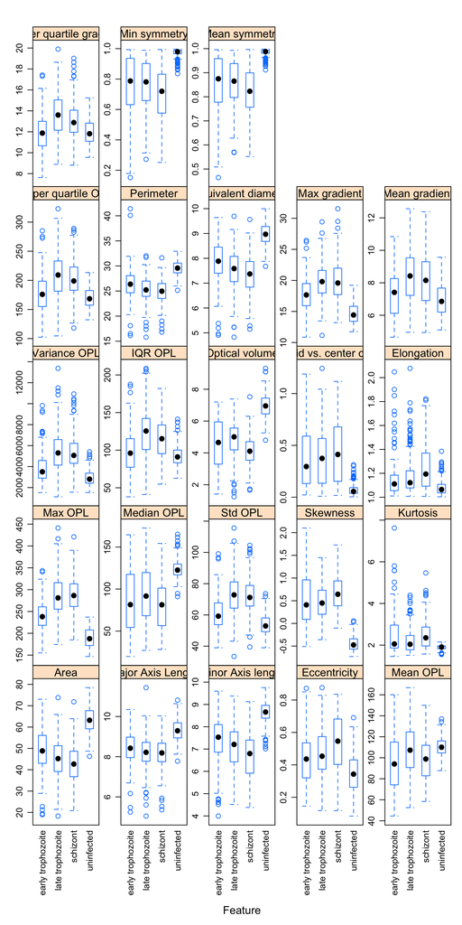

```r
featurePlot(x = morphologyTrain,
            y = stageTrain,
            plot = "box",
            ## Pass in options to bwplot()
            scales = list(y = list(relation="free"),
                          x = list(rot = 90)),
            layout = c(5,5))
```

The variables in this data set are on different scales. In this situation it is important to centre and scale each predictor. A predictor variable is centered by subtracting the mean of the predictor from each value. To scale a predictor variable, each value is divided by its standard deviation. After centring and scaling the predictor variable has a mean of 0 and a standard deviation of 1.

Examine pairwise correlations of predictors to identify redundancy in data set

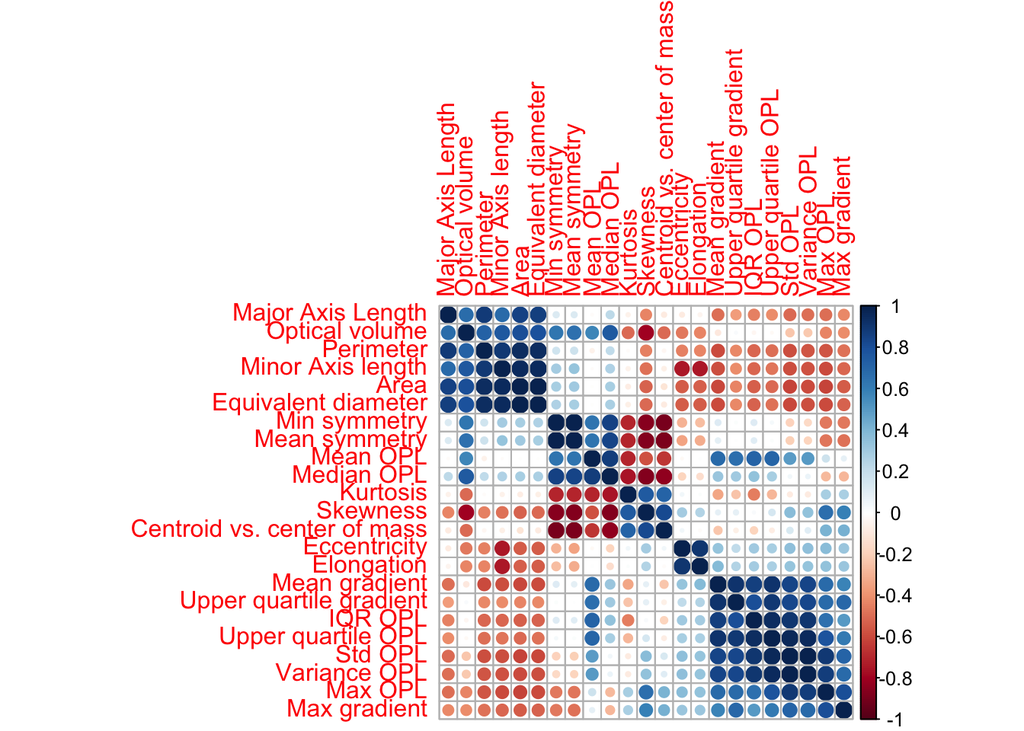

```r
corMat <- cor(morphologyTrain)
corrplot(corMat, order="hclust", tl.cex=1)
```

Find highly correlated predictors

```r
highCorr <- findCorrelation(corMat, cutoff=0.75)
length(highCorr)
```

```
## [1] 16
```

```r
names(morphologyTrain)[highCorr]
```

```
##  [1] "Max OPL"                 "Area"
##  [3] "Minor Axis length"       "Std OPL"
##  [5] "Equivalent diameter"     "Variance OPL"
##  [7] "Mean gradient"           "Skewness"
##  [9] "IQR OPL"                 "Optical volume"
## [11] "Upper quartile gradient" "Median OPL"
## [13] "Mean symmetry"           "Min symmetry"
## [15] "Major Axis Length"       "Elongation"
```

The box plots above can be used to examine each predictor for skewness. Alternatively, a density plot can be used

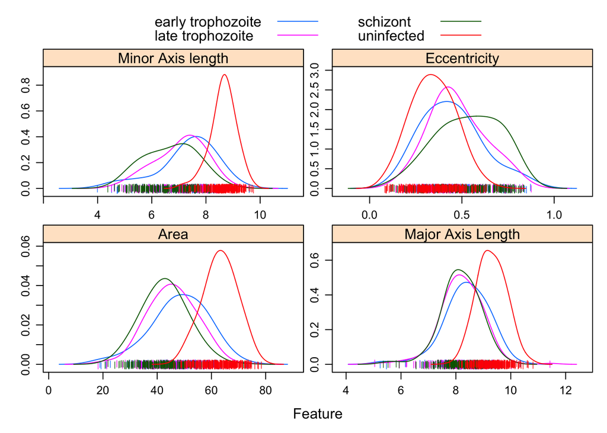

```r
featurePlot(x = morphologyTrain[,1:4],
            y = stageTrain,
            plot = "density",
            ## Pass in options to xyplot() to
            ## make it prettier
            scales = list(x = list(relation="free"),
                          y = list(relation="free")),
            adjust = 1.5,
            pch = "|",
            layout = c(2, 2),
            auto.key = list(columns = 2))
```

## Model training and parameter tuning

*k*-NN has only one parameter: the number of nearest neighbours *k*.

We will use repeated cross-validation to find the best value of *k*. Repeated cross-validation can readily be parallelized to increase speed of execution. All we need to do is create a local cluster - **caret** will then use this cluster to parallelize the cross-validation.

```r
registerDoMC(detectCores())
getDoParWorkers()
```

```
## [1] 4
```

The resampling method is specified using the **trainControl** function. To repeat five-fold cross validation a total of five times we would use:

```r
train_ctrl <- trainControl(method="repeatedcv",
                           number = 5,
                           repeats = 5)
```

To make the analysis reproducible we need to specify the seed for each resampling iteration.

```r
set.seed(42)
seeds <- vector(mode = "list", length = 26)
for(i in 1:25) seeds[[i]] <- sample.int(1000, 10)
seeds[[26]] <- sample.int(1000,1)

train_ctrl <- trainControl(method="repeatedcv",
                           number = 5,
                           repeats = 5,
                           seeds = seeds)
```

The **train** function is used to tune a model

```r
knnFit <- train(morphologyTrain, stageTrain,
                method="knn",
                preProcess = c("center", "scale"),
                #tuneGrid=tuneParam,
                tuneLength=10,
                trControl=train_ctrl)

knnFit
```

```
## k-Nearest Neighbors
##
## 868 samples
##  23 predictor
##   4 classes: 'early trophozoite', 'late trophozoite', 'schizont', 'uninfected'
##
## Pre-processing: centered (23), scaled (23)
## Resampling: Cross-Validated (5 fold, repeated 5 times)
## Summary of sample sizes: 695, 694, 695, 694, 694, 694, ...
## Resampling results across tuning parameters:
##
##   k   Accuracy   Kappa
##    5  0.6896166  0.5701456
##    7  0.6986087  0.5817862
##    9  0.6988439  0.5816238
##   11  0.7011375  0.5843709
##   13  0.6962939  0.5772133
##   15  0.6969955  0.5780448
##   17  0.6889217  0.5663867
##   19  0.6960680  0.5763382
##   21  0.6896206  0.5669881
##   23  0.6882254  0.5646115
##
## Accuracy was used to select the optimal model using the largest value.
## The final value used for the model was k = 11.
```

Plot the results of the cross-validation

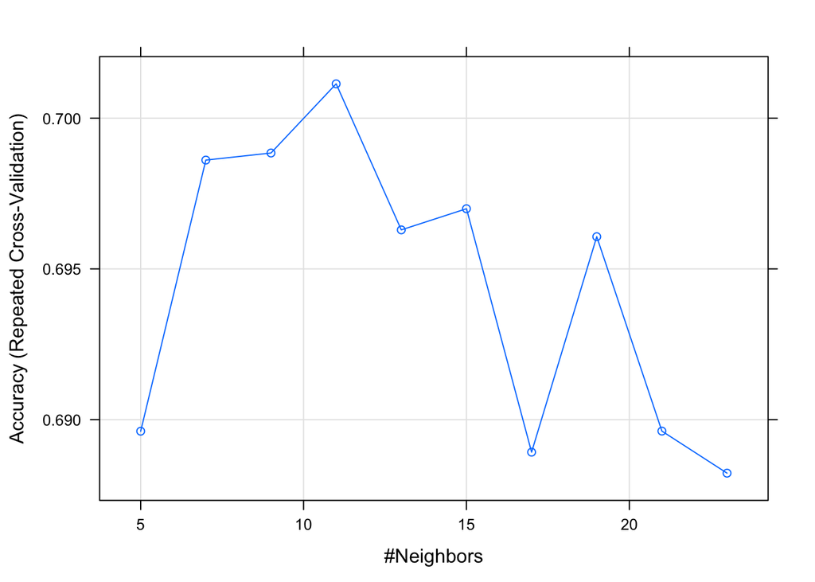

```r
plot(knnFit)
```

rf

```r
rfFit <- train(morphologyTrain, stageTrain,
                method="rf",
                preProcess = c("center", "scale"),
                #tuneGrid=tuneParam,
                tuneLength=10,
                trControl=train_ctrl)
rfFit
```

```
## Random Forest
##
## 868 samples
##  23 predictor
##   4 classes: 'early trophozoite', 'late trophozoite', 'schizont', 'uninfected'
##
## Pre-processing: centered (23), scaled (23)
## Resampling: Cross-Validated (5 fold, repeated 5 times)
## Summary of sample sizes: 693, 695, 695, 694, 695, 694, ...
## Resampling results across tuning parameters:
##
##   mtry  Accuracy   Kappa
##    2    0.7184462  0.6121623
##    4    0.7179838  0.6120214
##    6    0.7232845  0.6196398
##    9    0.7248884  0.6221363
##   11    0.7209591  0.6167334
##   13    0.7230175  0.6196534
##   16    0.7195890  0.6150192
##   18    0.7181885  0.6132322
##   20    0.7184422  0.6133707
##   23    0.7149754  0.6086754
##
## Accuracy was used to select the optimal model using the largest value.
## The final value used for the model was mtry = 9.
```

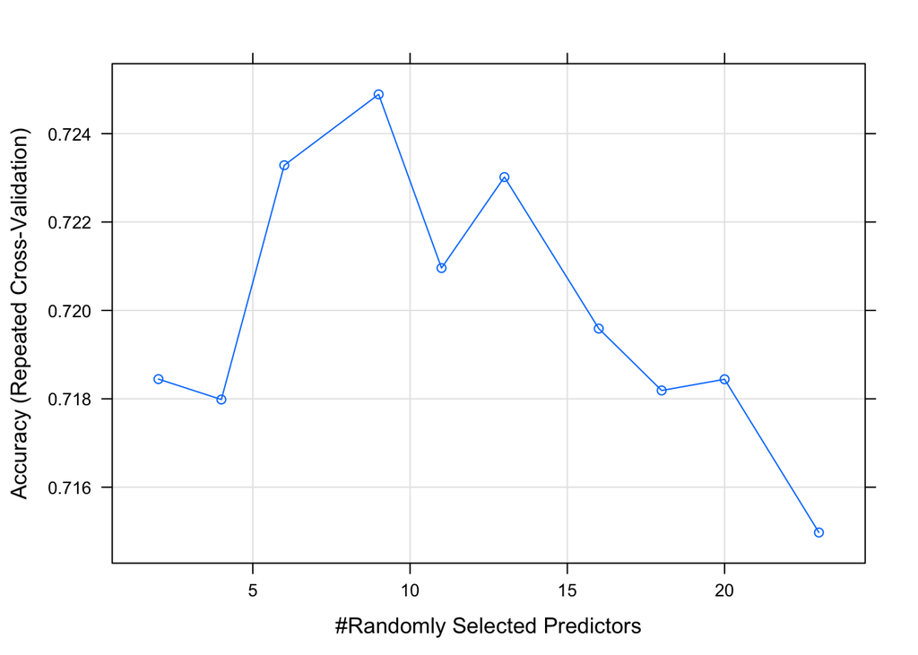

```r
plot(rfFit)
```

svm

```r
svmFit <- train(morphologyTrain, stageTrain,
                method="svmRadialCost",
                preProcess = c("center", "scale"),
                #tuneGrid=tuneParam,
                tuneLength=10,
                trControl=train_ctrl)

svmFit
```

```
## Support Vector Machines with Radial Basis Function Kernel
##
## 868 samples
##  23 predictor
##   4 classes: 'early trophozoite', 'late trophozoite', 'schizont', 'uninfected'
##
## Pre-processing: centered (23), scaled (23)
## Resampling: Cross-Validated (5 fold, repeated 5 times)
## Summary of sample sizes: 694, 694, 695, 694, 695, 695, ...
## Resampling results across tuning parameters:
##
##   C       Accuracy   Kappa
##     0.25  0.7154329  0.6047506
##     0.50  0.7214139  0.6148891
##     1.00  0.7258003  0.6215590
##     2.00  0.7269590  0.6236982
##     4.00  0.7223400  0.6177488
##     8.00  0.7177397  0.6118332
##    16.00  0.7002139  0.5887655
##    32.00  0.6882320  0.5734060
##    64.00  0.6681882  0.5466042
##   128.00  0.6591974  0.5348432
##
## Accuracy was used to select the optimal model using the largest value.
## The final value used for the model was C = 2.
```

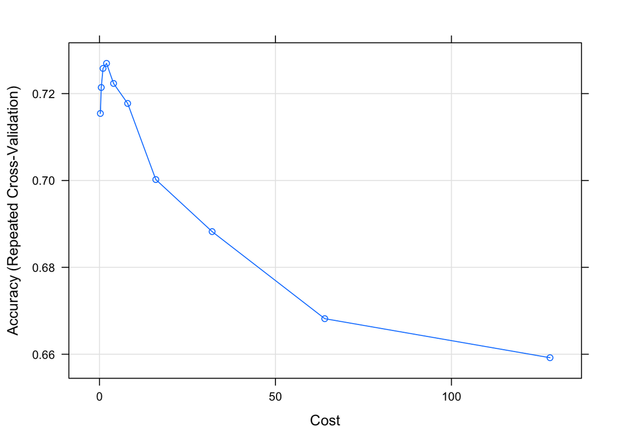

```r
plot(svmFit)
```

Predict test set and tabulate results in a confusion matrix

```r
test_pred <- predict(svmFit, morphologyTest)
confusionMatrix(test_pred, stageTest)
```

```
## Confusion Matrix and Statistics
##
##                    Reference
## Prediction          early trophozoite late trophozoite schizont uninfected
##   early trophozoite                22                4       10          3
##   late trophozoite                 19               56       25          0
##   schizont                          6               33       66          0
##   uninfected                        4                1        0        120
##
## Overall Statistics
##
##                Accuracy : 0.7154
##                  95% CI : (0.6665, 0.7609)
##     No Information Rate : 0.3333
##     P-Value [Acc > NIR] : < 2.2e-16
##
##                   Kappa : 0.6078
##  Mcnemar's Test P-Value : NA
##
## Statistics by Class:
##
##                      Class: early trophozoite Class: late trophozoite
## Sensitivity                           0.43137                  0.5957
## Specificity                           0.94654                  0.8400
## Pos Pred Value                        0.56410                  0.5600
## Neg Pred Value                        0.91212                  0.8587
## Prevalence                            0.13821                  0.2547
## Detection Rate                        0.05962                  0.1518
## Detection Prevalence                  0.10569                  0.2710
## Balanced Accuracy                     0.68896                  0.7179
##                      Class: schizont Class: uninfected
## Sensitivity                   0.6535            0.9756
## Specificity                   0.8545            0.9797
## Pos Pred Value                0.6286            0.9600
## Neg Pred Value                0.8674            0.9877
## Prevalence                    0.2737            0.3333
## Detection Rate                0.1789            0.3252
## Detection Prevalence          0.2846            0.3388
## Balanced Accuracy             0.7540            0.9776
```